# 人脸生成（Face Generation）

在该项目中，你将使用生成式对抗网络（Generative Adversarial Nets）来生成新的人脸图像。

### 获取数据

该项目将使用以下数据集：

- MNIST
- CelebA

由于 CelebA 数据集比较复杂，而且这是你第一次使用 GANs。我们想让你先在 MNIST 数据集上测试你的 GANs 模型，以让你更快的评估所建立模型的性能。

如果你在使用 [FloydHub](https://www.floydhub.com/), 请将 `data_dir` 设置为 "/input" 并使用 [FloydHub data ID](http://docs.floydhub.com/home/using_datasets/) "R5KrjnANiKVhLWAkpXhNBe".

```python
data_dir = './data'

# FloydHub - Use with data ID "R5KrjnANiKVhLWAkpXhNBe"
#data_dir = '/input'


"""
DON'T MODIFY ANYTHING IN THIS CELL
"""
import helper

helper.download_extract('mnist', data_dir)
helper.download_extract('celeba', data_dir)
```

```
Found mnist Data
Found celeba Data
```

## 探索数据（Explore the Data）

### MNIST

[MNIST](http://yann.lecun.com/exdb/mnist/) 是一个手写数字的图像数据集。你可以更改 `show_n_images` 探索此数据集。

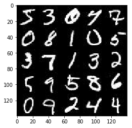

```python
show_n_images = 25

"""
DON'T MODIFY ANYTHING IN THIS CELL
"""
%matplotlib inline
import os
from glob import glob
from matplotlib import pyplot

mnist_images = helper.get_batch(glob(os.path.join(data_dir, 'mnist/*.jpg'))[:show_n_images], 28, 28, 'L')
pyplot.imshow(helper.images_square_grid(mnist_images, 'L'), cmap='gray')
```

### CelebA

[CelebFaces Attributes Dataset (CelebA)](http://mmlab.ie.cuhk.edu.hk/projects/CelebA.html) 是一个包含 20 多万张名人图片及相关图片说明的数据集。你将用此数据集生成人脸，不会用不到相关说明。你可以更改 `show_n_images` 探索此数据集。

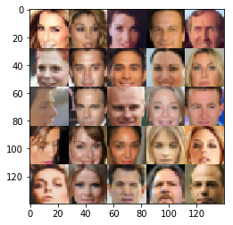

```python
show_n_images = 25

"""
DON'T MODIFY ANYTHING IN THIS CELL
"""
mnist_images = helper.get_batch(glob(os.path.join(data_dir, 'img_align_celeba/*.jpg'))[:show_n_images], 28, 28, 'RGB')
pyplot.imshow(helper.images_square_grid(mnist_images, 'RGB'))
```

## 预处理数据（Preprocess the Data）

由于该项目的重点是建立 GANs 模型，我们将为你预处理数据。

经过数据预处理，MNIST 和 CelebA 数据集的值在 28×28 维度图像的 [-0.5, 0.5] 范围内。CelebA 数据集中的图像裁剪了非脸部的图像部分，然后调整到 28x28 维度。

MNIST 数据集中的图像是单通道的黑白图像，CelebA 数据集中的图像是 三通道的 RGB 彩色图像。

## 建立神经网络（Build the Neural Network）

你将通过部署以下函数来建立 GANs 的主要组成部分:

- `model_inputs`
- `discriminator`
- `generator`
- `model_loss`
- `model_opt`
- `train`

### 检查 TensorFlow 版本并获取 GPU 型号

检查你是否使用正确的 TensorFlow 版本，并获取 GPU 型号

```python
"""
DON'T MODIFY ANYTHING IN THIS CELL
"""
from distutils.version import LooseVersion
import warnings
import tensorflow as tf

# Check TensorFlow Version
assert LooseVersion(tf.__version__) >= LooseVersion('1.0'), 'Please use TensorFlow version 1.0 or newer.  You are using {}'.format(tf.__version__)
print('TensorFlow Version: {}'.format(tf.__version__))

# Check for a GPU
if not tf.test.gpu_device_name():
    warnings.warn('No GPU found. Please use a GPU to train your neural network.')
else:
    print('Default GPU Device: {}'.format(tf.test.gpu_device_name()))
```

```
TensorFlow Version: 1.0.1
Default GPU Device: /gpu:0
```

### 输入（Input）

部署 `model_inputs` 函数以创建用于神经网络的 [占位符 (TF Placeholders)](https://www.tensorflow.org/versions/r0.11/api_docs/python/io_ops/placeholders)。请创建以下占位符：

- 输入图像占位符: 使用 `image_width`，`image_height` 和 `image_channels` 设置为 rank 4。
- 输入 Z 占位符: 设置为 rank 2，并命名为 `z_dim`。
- 学习速率占位符: 设置为 rank 0。

返回占位符元组的形状为 (tensor of real input images, tensor of z data, learning rate)。

```python
import problem_unittests as tests

def model_inputs(image_width, image_height, image_channels, z_dim):
    """
    Create the model inputs
    :param image_width: The input image width
    :param image_height: The input image height
    :param image_channels: The number of image channels
    :param z_dim: The dimension of Z
    :return: Tuple of (tensor of real input images, tensor of z data, learning rate)
    """
    # TODO: Implement Function
    inputs_real = tf.placeholder(tf.float32, (None, image_width, image_height, image_channels), name='input_real')
    inputs_z = tf.placeholder(tf.float32, (None, z_dim), name='input_z')
    lr = tf.placeholder(tf.float32, name='learning_rate')

    return inputs_real, inputs_z, lr


"""
DON'T MODIFY ANYTHING IN THIS CELL THAT IS BELOW THIS LINE
"""
tests.test_model_inputs(model_inputs)
```

```
Tests Passed
```

### 辨别器（Discriminator）

部署 `discriminator` 函数创建辨别器神经网络以辨别 `images`。该函数应能够重复使用神经网络中的各种变量。 在 [`tf.variable_scope`](https://www.tensorflow.org/api_docs/python/tf/variable_scope) 中使用 "discriminator" 的变量空间名来重复使用该函数中的变量。

该函数应返回形如 (tensor output of the discriminator, tensor logits of the discriminator) 的元组。

```python
def discriminator(images, reuse=False):
    """
    Create the discriminator network
    :param image: Tensor of input image(s)
    :param reuse: Boolean if the weights should be reused
    :return: Tuple of (tensor output of the discriminator, tensor logits of the discriminator)
    """
    # TODO: Implement Function
    alpha=0.2
    with tf.variable_scope('discriminator', reuse=reuse):
        # Input layer is 28x28x3
        x1 = tf.layers.conv2d(images, 64, 5, strides=2, padding='same')
        relu1 = tf.maximum(alpha * x1, x1)
        # 14x14x64

        x2 = tf.layers.conv2d(relu1, 128, 5, strides=2, padding='same')
        bn2 = tf.layers.batch_normalization(x2, training=True)
        relu2 = tf.maximum(alpha * bn2, bn2)
        # 7x7x128

        x3 = tf.layers.conv2d(relu2, 256, 5, strides=2, padding='same')
        bn3 = tf.layers.batch_normalization(x3, training=True)
        relu3 = tf.maximum(alpha * bn3, bn3)
        # 4x4x256

        # Flatten it
        flat = tf.reshape(relu3, (-1, 4*4*256))
        logits = tf.layers.dense(flat, 1)
        out = tf.sigmoid(logits)

        return out, logits


"""
DON'T MODIFY ANYTHING IN THIS CELL THAT IS BELOW THIS LINE
"""
tests.test_discriminator(discriminator, tf)
```

```
Tests Passed
```

### 生成器（Generator）

部署 `generator` 函数以使用 `z` 生成图像。该函数应能够重复使用神经网络中的各种变量。 在 [`tf.variable_scope`](https://www.tensorflow.org/api_docs/python/tf/variable_scope) 中使用 "generator" 的变量空间名来重复使用该函数中的变量。

该函数应返回所生成的 28 x 28 x `out_channel_dim` 维度图像。

```python
def generator(z, out_channel_dim, is_train=True):
    """
    Create the generator network
    :param z: Input z
    :param out_channel_dim: The number of channels in the output image
    :param is_train: Boolean if generator is being used for training
    :return: The tensor output of the generator
    """
    # TODO: Implement Function
    alpha = 0.2
    with tf.variable_scope('generator', reuse=not is_train):
        # First fully connected layer
        x1 = tf.layers.dense(z, 3*3*512)
        # Reshape it to start the convolutional stack
        x1 = tf.reshape(x1, (-1, 3, 3, 512))
        x1 = tf.layers.batch_normalization(x1, training=is_train)
        x1 = tf.maximum(alpha * x1, x1)

        x2 = tf.layers.conv2d_transpose(x1, 256, 5, strides=1, padding='valid')
        x2 = tf.layers.batch_normalization(x2, training=is_train)
        x2 = tf.maximum(alpha * x2, x2)

        x3 = tf.layers.conv2d_transpose(x2, 128, 5, strides=2, padding='same')
        x3 = tf.layers.batch_normalization(x3, training=is_train)
        x3 = tf.maximum(alpha * x3, x3)

        # Output layer
        logits = tf.layers.conv2d_transpose(x3, out_channel_dim, 5, strides=2, padding='same')
        # 28x28x out_channel_dim now

        out = tf.tanh(logits)

        return out

"""
DON'T MODIFY ANYTHING IN THIS CELL THAT IS BELOW THIS LINE
"""
tests.test_generator(generator, tf)
```

```
Tests Passed
```

### 损失函数（Loss）

部署 `model_loss` 函数训练并计算 GANs 的损失。该函数应返回形如 (discriminator loss, generator loss) 的元组。

使用你已实现的函数：

- `discriminator(images, reuse=False)`
- `generator(z, out_channel_dim, is_train=True)`

```python
def model_loss(input_real, input_z, out_channel_dim):
    """
    Get the loss for the discriminator and generator
    :param input_real: Images from the real dataset
    :param input_z: Z input
    :param out_channel_dim: The number of channels in the output image
    :return: A tuple of (discriminator loss, generator loss)
    """
    # TODO: Implement Function

    g_model = generator(input_z, out_channel_dim)
    d_model_real, d_logits_real = discriminator(input_real)
    d_model_fake, d_logits_fake = discriminator(g_model, reuse=True)

    d_loss_real = tf.reduce_mean(
        tf.nn.sigmoid_cross_entropy_with_logits(logits=d_logits_real, labels=tf.ones_like(d_model_real)))
    d_loss_fake = tf.reduce_mean(
        tf.nn.sigmoid_cross_entropy_with_logits(logits=d_logits_fake, labels=tf.zeros_like(d_model_fake)))
    g_loss = tf.reduce_mean(
        tf.nn.sigmoid_cross_entropy_with_logits(logits=d_logits_fake, labels=tf.ones_like(d_model_fake)))

    d_loss = d_loss_real + d_loss_fake

    return d_loss, g_loss

"""
DON'T MODIFY ANYTHING IN THIS CELL THAT IS BELOW THIS LINE
"""
tests.test_model_loss(model_loss)
```

```
Tests Passed
```

### 优化（Optimization）

部署 `model_opt` 函数实现对 GANs 的优化。使用 [`tf.trainable_variables`](https://www.tensorflow.org/api_docs/python/tf/trainable_variables) 获取可训练的所有变量。通过变量空间名 `discriminator` 和 `generator` 来过滤变量。该函数应返回形如 (discriminator training operation, generator training operation) 的元组。

```python
def model_opt(d_loss, g_loss, learning_rate, beta1):
    """
    Get optimization operations
    :param d_loss: Discriminator loss Tensor
    :param g_loss: Generator loss Tensor
    :param learning_rate: Learning Rate Placeholder
    :param beta1: The exponential decay rate for the 1st moment in the optimizer
    :return: A tuple of (discriminator training operation, generator training operation)
    """
    # TODO: Implement Function
    # Get weights and bias to update
    t_vars = tf.trainable_variables()
    d_vars = [var for var in t_vars if var.name.startswith('discriminator')]
    g_vars = [var for var in t_vars if var.name.startswith('generator')]

    # Optimize
    with tf.control_dependencies(tf.get_collection(tf.GraphKeys.UPDATE_OPS)):
        d_train_opt = tf.train.AdamOptimizer(learning_rate, beta1=beta1).minimize(d_loss, var_list=d_vars)
        g_train_opt = tf.train.AdamOptimizer(learning_rate, beta1=beta1).minimize(g_loss, var_list=g_vars)

    return d_train_opt, g_train_opt


"""
DON'T MODIFY ANYTHING IN THIS CELL THAT IS BELOW THIS LINE
"""
tests.test_model_opt(model_opt, tf)
```

```
Tests Passed
```

## 训练神经网络（Neural Network Training）

### 输出显示

使用该函数可以显示生成器 (Generator) 在训练过程中的当前输出，这会帮你评估 GANs 模型的训练程度。

```python
"""
DON'T MODIFY ANYTHING IN THIS CELL
"""
import numpy as np

def show_generator_output(sess, n_images, input_z, out_channel_dim, image_mode):
    """
    Show example output for the generator
    :param sess: TensorFlow session
    :param n_images: Number of Images to display
    :param input_z: Input Z Tensor
    :param out_channel_dim: The number of channels in the output image
    :param image_mode: The mode to use for images ("RGB" or "L")
    """
    cmap = None if image_mode == 'RGB' else 'gray'
    z_dim = input_z.get_shape().as_list()[-1]
    example_z = np.random.uniform(-1, 1, size=[n_images, z_dim])

    samples = sess.run(
        generator(input_z, out_channel_dim, False),
        feed_dict={input_z: example_z})

    images_grid = helper.images_square_grid(samples, image_mode)
    pyplot.imshow(images_grid, cmap=cmap)
    pyplot.show()
```

### 训练

部署 `train` 函数以建立并训练 GANs 模型。记得使用以下你已完成的函数：

- `model_inputs(image_width, image_height, image_channels, z_dim)`
- `model_loss(input_real, input_z, out_channel_dim)`
- `model_opt(d_loss, g_loss, learning_rate, beta1)`

使用 `show_generator_output` 函数显示 `generator` 在训练过程中的输出。

**注意**：在每个批次 (batch) 中运行 `show_generator_output` 函数会显著增加训练时间与该 notebook 的体积。推荐每 100 批次输出一次 `generator` 的输出。

```python
def train(epoch_count, batch_size, z_dim, learning_rate, beta1, get_batches, data_shape, data_image_mode):
    """
    Train the GAN
    :param epoch_count: Number of epochs
    :param batch_size: Batch Size
    :param z_dim: Z dimension
    :param learning_rate: Learning Rate
    :param beta1: The exponential decay rate for the 1st moment in the optimizer
    :param get_batches: Function to get batches
    :param data_shape: Shape of the data
    :param data_image_mode: The image mode to use for images ("RGB" or "L")
    """
    # TODO: Build Model
    print_every =100
    show_every =500

    input_real, input_z, lr = model_inputs(data_shape[1], data_shape[2], data_shape[3], z_dim)
    d_loss, g_loss = model_loss(input_real, input_z, data_shape[3])
    d_opt, g_opt = model_opt(d_loss, g_loss, lr, beta1)
#     print(input_real, input_z, lr)

#     saver = tf.train.Saver()
    sample_z = np.random.uniform(-1, 1, size=(100, z_dim))
    samples, losses = [], []
    steps = 0

    with tf.Session() as sess:
        sess.run(tf.global_variables_initializer())
        for epoch_i in range(epoch_count):
            for batch_images in get_batches(batch_size):
                # TODO: Train Model
                steps += 1

                # Sample random noise for G
                batch_z = np.random.uniform(-1, 1, size=(batch_size, z_dim))

                # Run optimizers
                _ = sess.run(d_opt, feed_dict={input_real: batch_images, input_z: batch_z, lr: learning_rate})
                _ = sess.run(g_opt, feed_dict={input_real: batch_images, input_z: batch_z, lr: learning_rate})

                if steps % print_every == 0:
                    # At the end of each epoch, get the losses and print them out
                    train_loss_d = d_loss.eval({input_z: batch_z, input_real: batch_images})
                    train_loss_g = g_loss.eval({input_z: batch_z})

                    print("Steps {}...".format(steps+1),
                          "Discriminator Loss: {:.4f}...".format(train_loss_d),
                          "Generator Loss: {:.4f}".format(train_loss_g))
                    # Save losses to view after training
                    losses.append((train_loss_d, train_loss_g))

                if steps % show_every == 0:
                    _ = show_generator_output(sess, 25, input_z, data_shape[3], data_image_mode)#sess, n_images, input_z, out_channel_dim, image_mode

#         saver.save(sess, './checkpoints/generator.ckpt')

#     with open('samples.pkl', 'wb') as f:
#         pkl.dump(samples, f)

    return losses, samples
```

### MNIST

在 MNIST 上测试你的 GANs 模型。经过 2 次迭代，GANs 应该能够生成类似手写数字的图像。确保生成器 (generator) 低于辨别器 (discriminator) 的损失，或接近 0。

[output not shown]

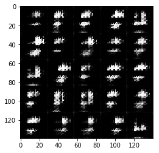

[output not shown]

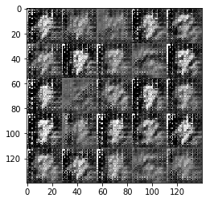

[output not shown]

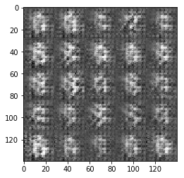

[output not shown]

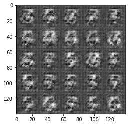

[output not shown]

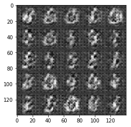

[output not shown]

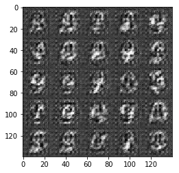

[output not shown]

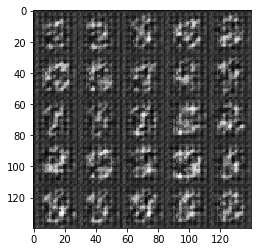

[output not shown]

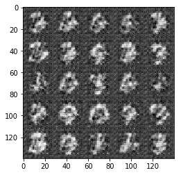

[output not shown]

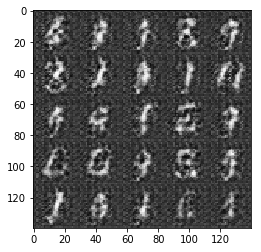

[output not shown]

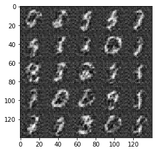

[output not shown]

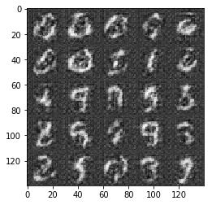

[output not shown]

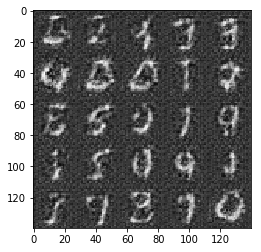

[output not shown]

[20 more figures not shown]

```python
batch_size = 25
z_dim = 100
learning_rate = 0.001
beta1 = 0.5


"""
DON'T MODIFY ANYTHING IN THIS CELL THAT IS BELOW THIS LINE
"""
epochs = 2

mnist_dataset = helper.Dataset('mnist', glob(os.path.join(data_dir, 'mnist/*.jpg')))
with tf.Graph().as_default():
    train(epochs, batch_size, z_dim, learning_rate, beta1, mnist_dataset.get_batches,
          mnist_dataset.shape, mnist_dataset.image_mode)
```

### CelebA

在 CelebA 上运行你的 GANs 模型。在一般的GPU上运行每次迭代大约需要 20 分钟。你可以运行整个迭代，或者当 GANs 开始产生真实人脸图像时停止它。

```
Steps 101... Discriminator Loss: 0.0215... Generator Loss: 4.3143
Steps 201... Discriminator Loss: 1.1610... Generator Loss: 5.1632
Steps 301... Discriminator Loss: 0.1122... Generator Loss: 3.2862
Steps 401... Discriminator Loss: 4.5316... Generator Loss: 0.4079
Steps 501... Discriminator Loss: 1.2279... Generator Loss: 1.6134
```

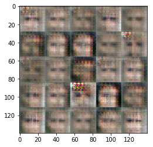

```
Steps 601... Discriminator Loss: 0.4728... Generator Loss: 1.4142
Steps 701... Discriminator Loss: 0.6063... Generator Loss: 2.2891
Steps 801... Discriminator Loss: 0.7916... Generator Loss: 1.9185
Steps 901... Discriminator Loss: 1.2049... Generator Loss: 0.5146
Steps 1001... Discriminator Loss: 0.4777... Generator Loss: 2.1636
```

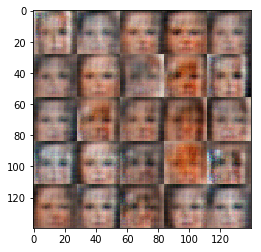

```
Steps 1101... Discriminator Loss: 0.8405... Generator Loss: 3.3589
Steps 1201... Discriminator Loss: 1.4593... Generator Loss: 0.3797
Steps 1301... Discriminator Loss: 0.7683... Generator Loss: 2.2944
Steps 1401... Discriminator Loss: 2.8566... Generator Loss: 0.1009
Steps 1501... Discriminator Loss: 0.8104... Generator Loss: 1.4927
```

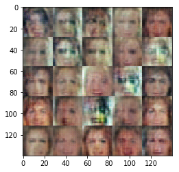

```
Steps 1601... Discriminator Loss: 0.7677... Generator Loss: 1.9735
Steps 1701... Discriminator Loss: 0.6238... Generator Loss: 1.3579
Steps 1801... Discriminator Loss: 1.3594... Generator Loss: 0.4498
Steps 1901... Discriminator Loss: 0.8127... Generator Loss: 1.1399
Steps 2001... Discriminator Loss: 1.1134... Generator Loss: 0.7254
```

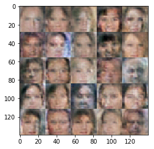

```
Steps 2101... Discriminator Loss: 0.7677... Generator Loss: 0.9758
Steps 2201... Discriminator Loss: 0.9075... Generator Loss: 1.1600
Steps 2301... Discriminator Loss: 0.8237... Generator Loss: 2.2282
Steps 2401... Discriminator Loss: 1.0107... Generator Loss: 1.2494
Steps 2501... Discriminator Loss: 0.9908... Generator Loss: 1.4595
```

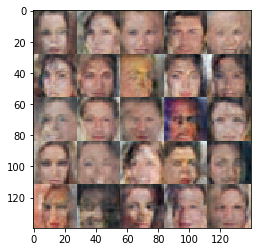

```
Steps 2601... Discriminator Loss: 0.8060... Generator Loss: 0.9347
Steps 2701... Discriminator Loss: 1.2992... Generator Loss: 1.1079
Steps 2801... Discriminator Loss: 0.6544... Generator Loss: 1.2544
Steps 2901... Discriminator Loss: 1.1704... Generator Loss: 2.5042
Steps 3001... Discriminator Loss: 1.3075... Generator Loss: 0.6845
```

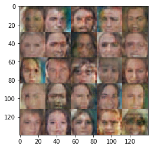

```
Steps 3101... Discriminator Loss: 0.9417... Generator Loss: 0.9691
Steps 3201... Discriminator Loss: 0.9328... Generator Loss: 0.6745
Steps 3301... Discriminator Loss: 1.0079... Generator Loss: 0.7735
Steps 3401... Discriminator Loss: 0.8346... Generator Loss: 1.0638
Steps 3501... Discriminator Loss: 0.8244... Generator Loss: 1.6242
```

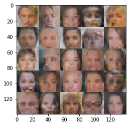

```
Steps 3601... Discriminator Loss: 1.1980... Generator Loss: 0.5130
Steps 3701... Discriminator Loss: 0.9657... Generator Loss: 1.7303
Steps 3801... Discriminator Loss: 0.7892... Generator Loss: 1.3858
Steps 3901... Discriminator Loss: 1.4786... Generator Loss: 0.3895
Steps 4001... Discriminator Loss: 1.5752... Generator Loss: 0.3337
```

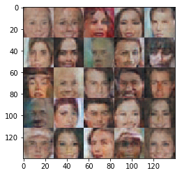

```
Steps 4101... Discriminator Loss: 1.5801... Generator Loss: 0.3349
Steps 4201... Discriminator Loss: 1.5072... Generator Loss: 0.3754
Steps 4301... Discriminator Loss: 0.7165... Generator Loss: 1.0724
Steps 4401... Discriminator Loss: 0.7131... Generator Loss: 1.2147
Steps 4501... Discriminator Loss: 1.3157... Generator Loss: 0.5769
```

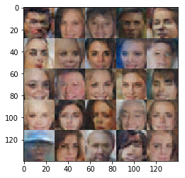

```
Steps 4601... Discriminator Loss: 1.1017... Generator Loss: 0.6403
Steps 4701... Discriminator Loss: 1.4364... Generator Loss: 2.5628
Steps 4801... Discriminator Loss: 1.2413... Generator Loss: 1.2591
Steps 4901... Discriminator Loss: 1.2384... Generator Loss: 0.6098
Steps 5001... Discriminator Loss: 1.1954... Generator Loss: 0.5589
```

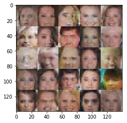

```
Steps 5101... Discriminator Loss: 1.0562... Generator Loss: 0.9214
Steps 5201... Discriminator Loss: 1.5631... Generator Loss: 0.3308
Steps 5301... Discriminator Loss: 1.0514... Generator Loss: 0.8923
Steps 5401... Discriminator Loss: 1.0628... Generator Loss: 1.7914
Steps 5501... Discriminator Loss: 1.7296... Generator Loss: 1.4485
```

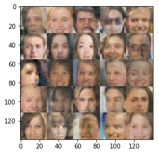

```
Steps 5601... Discriminator Loss: 0.6165... Generator Loss: 1.6400
Steps 5701... Discriminator Loss: 1.0807... Generator Loss: 0.9354
Steps 5801... Discriminator Loss: 0.9791... Generator Loss: 0.7855
Steps 5901... Discriminator Loss: 1.1730... Generator Loss: 0.7446
Steps 6001... Discriminator Loss: 4.2011... Generator Loss: 4.2217
```

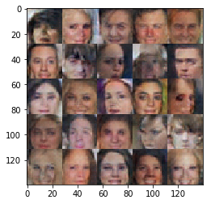

```
Steps 6101... Discriminator Loss: 1.2011... Generator Loss: 0.7085
Steps 6201... Discriminator Loss: 1.1328... Generator Loss: 0.7375
Steps 6301... Discriminator Loss: 1.0019... Generator Loss: 0.7849
Steps 6401... Discriminator Loss: 0.9930... Generator Loss: 0.8134
Steps 6501... Discriminator Loss: 0.7396... Generator Loss: 0.9575
```

[2 more figures not shown]

```
Steps 7101... Discriminator Loss: 0.1438... Generator Loss: 3.0758
Steps 7201... Discriminator Loss: 1.2982... Generator Loss: 0.6181
Steps 7301... Discriminator Loss: 1.1744... Generator Loss: 0.5839
```

[output not shown]

```python
batch_size = 128
z_dim = 100
learning_rate = 0.002
beta1 = 0.5


"""
DON'T MODIFY ANYTHING IN THIS CELL THAT IS BELOW THIS LINE
"""
epochs = 5

celeba_dataset = helper.Dataset('celeba', glob(os.path.join(data_dir, 'img_align_celeba/*.jpg')))
with tf.Graph().as_default():
    train(epochs, batch_size, z_dim, learning_rate, beta1, celeba_dataset.get_batches,
          celeba_dataset.shape, celeba_dataset.image_mode)
```

### 提交项目

提交本项目前，确保运行所有 cells 后保存该文件。

保存该文件为 "dlnd_face_generation.ipynb"， 并另存为 HTML 格式 "File" -> "Download as"。提交项目时请附带 "helper.py" 和 "problem_unittests.py" 文件。